# Tugas Pertemuan 2

Anastasia Salma Irwansyah - M0401241041

## Library / Packages

```r
library(forecast)
library(TTR)
```

```r
library(readxl)
library(ggplot2)
```

## Impor Data

```r
datampdw1 <- read_excel("C:/Users/anast/Documents/coolyeah/SMT 5/Metode Peramalan Deret Waktu/mpdw/Pertemuan 2/data mpdw.xlsx", sheet = "orang 4")
head(datampdw1)
```

```
## # A tibble: 6 × 2
##   timestamp global_temperature_anomaly_C
##   <chr>                            <dbl>
## 1 2009-12                           0.67
## 2 2010-01                           0.75
## 3 2010-02                           0.84
## 4 2010-03                           0.92
## 5 2010-04                           0.85
## 6 2010-05                           0.75
```

## Eksplorasi Data

```r
View(datampdw1)
str(datampdw1)
```

```
## tibble [100 × 2] (S3: tbl_df/tbl/data.frame)
##  $ timestamp                   : chr [1:100] "2009-12" "2010-01" "2010-02" "2010-03" ...
##  $ global_temperature_anomaly_C: num [1:100] 0.67 0.75 0.84 0.92 0.85 0.75 0.68 0.63 0.67 0.63 ...
```

```r
dim(datampdw1)
```

```
## [1] 100   2
```

Mengubah data agar terbaca sebagai data deret waktu dengan fungsi `ts()` .

```r
datampdw1.ts <- ts(datampdw1$global_temperature_anomaly_C)
```

Menampilkan ringkasan data

```r
summary(datampdw1.ts)
```

```
##    Min. 1st Qu.  Median    Mean 3rd Qu.    Max.
##  0.4500  0.6575  0.7750  0.7796  0.8700  1.3600
```

Membuat plot data deret waktu

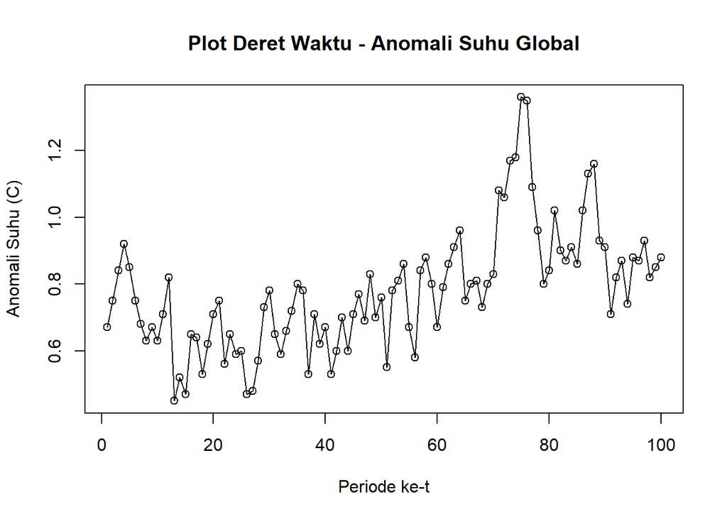

```r
ts.plot(datampdw1.ts, xlab = "Periode ke-t", ylab = "Anomali Suhu (C)",
        main = "Plot Deret Waktu - Anomali Suhu Global")
points(datampdw1.ts)
```

## Pembagian Data Latih dan Data Uji

Data dibagi 80% data latih dan 20% data uji

```r
# hitung jumlah data
n <- nrow(datampdw1)

# tentukan batas 80%
n_train <- floor(0.8 * n)

# bagi data
training <- datampdw1[1:n_train, ]
testing  <- datampdw1[(n_train + 1):n, ]

# ubah ke time series
train.ts <- ts(training$global_temperature_anomaly_C)
test.ts  <- ts(testing$global_temperature_anomaly_C)

# jumlah data uji, dipakai otomatis di h=n_test & perhitungan error
n_test <- nrow(testing)
n_train; n_test
```

```
## [1] 80
```

```
## [1] 20
```

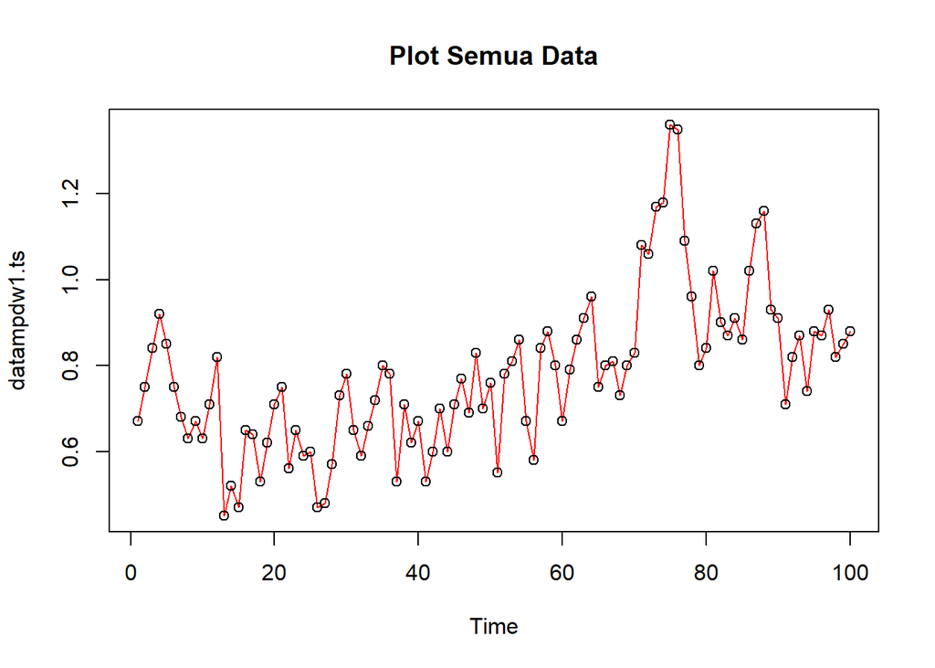

```r
#eksplorasi keseluruhan data
plot(datampdw1.ts, col = "red", main = "Plot Semua Data")
points(datampdw1.ts)
```

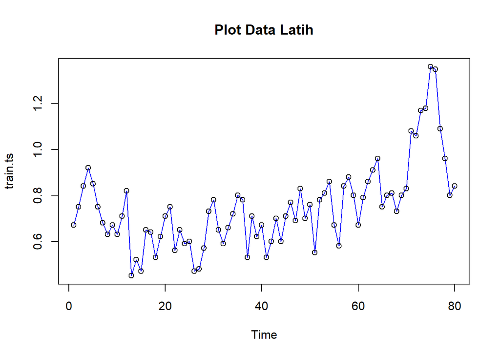

```r
#eksplorasi data latih
plot(train.ts, col = "blue", main = "Plot Data Latih")
points(train.ts)
```

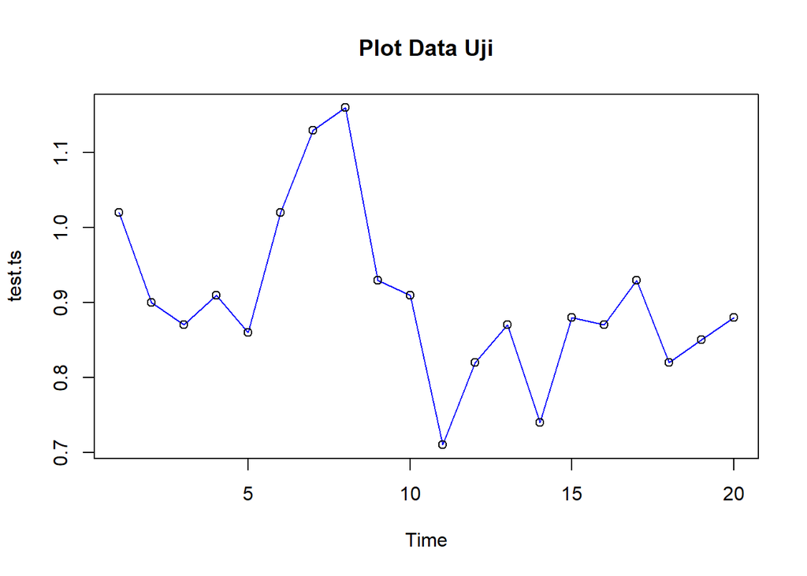

```r
#eksplorasi data uji
plot(test.ts, col = "blue", main = "Plot Data Uji")
points(test.ts)
```

Plot data latih menunjukkan fluktuasi naik-turun di sekitar level yang perlahan meningkat, sedangkan plot data uji menunjukkan pola berosilasi di kisaran 0,7-1,16°C tanpa kenaikan yang jelas melanjutkan tren akhir data latih.

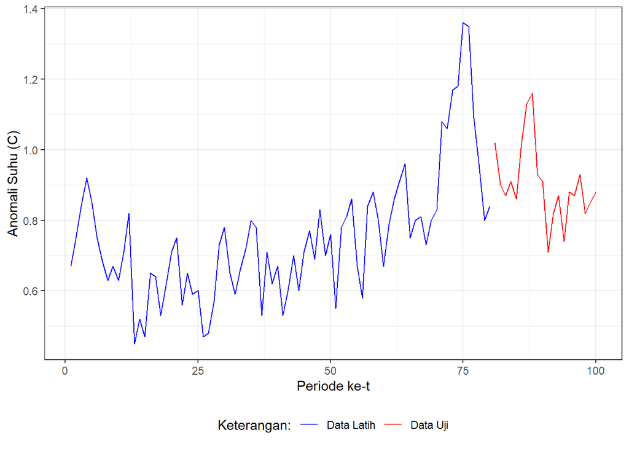

```r
ggplot() +
  geom_line(data = training, aes(x = seq_along(global_temperature_anomaly_C),
                                  y = global_temperature_anomaly_C, col = "Data Latih")) +
  geom_line(data = testing, aes(x = seq_along(global_temperature_anomaly_C) + n_train,
                                 y = global_temperature_anomaly_C, col = "Data Uji")) +
  labs(x = "Periode ke-t", y = "Anomali Suhu (C)") +
  scale_colour_manual(name = "Keterangan:", breaks = c("Data Latih", "Data Uji"),
                       values = c("blue", "red")) +
  theme_bw() + theme(legend.position = "bottom")
```

Plot gabungan menunjukkan bahwa data uji (merah) berada pada level yang mirip dengan bagian akhir data latih (biru), bukan pada level yang jauh lebih tinggi. Hal ini sesuai dengan indikasi bahwa tren jangka pendek tidak terlalu kuat untuk diekstrapolasi secara linier jauh ke depan.

## 1. Single Moving Average (SMA)

```r
data.sma <- SMA(train.ts, n = 4)
data.sma
```

```
## Time Series:
## Start = 1
## End = 80
## Frequency = 1
##  [1]     NA     NA     NA 0.7950 0.8400 0.8400 0.8000 0.7275 0.6825 0.6525
## [11] 0.6600 0.7075 0.6525 0.6250 0.5650 0.5225 0.5700 0.5725 0.6100 0.6250
## [21] 0.6525 0.6600 0.6675 0.6375 0.6000 0.5775 0.5350 0.5300 0.5625 0.6400
## [31] 0.6825 0.6875 0.6700 0.6550 0.6925 0.7400 0.7075 0.7050 0.6600 0.6325
## [41] 0.6325 0.6050 0.6250 0.6075 0.6525 0.6950 0.6925 0.7500 0.7475 0.7450
## [51] 0.7100 0.6975 0.7250 0.7500 0.7800 0.7300 0.7375 0.7425 0.7750 0.7975
## [61] 0.7850 0.7800 0.8075 0.8800 0.8700 0.8550 0.8300 0.7725 0.7850 0.7925
## [71] 0.8600 0.9425 1.0350 1.1225 1.1925 1.2650 1.2450 1.1900 1.0500 0.9225
```

```r
# forecast 1 periode ke depan
data.ramal <- c(NA, data.sma)
data.ramal
```

```
##  [1]     NA     NA     NA     NA 0.7950 0.8400 0.8400 0.8000 0.7275 0.6825
## [11] 0.6525 0.6600 0.7075 0.6525 0.6250 0.5650 0.5225 0.5700 0.5725 0.6100
## [21] 0.6250 0.6525 0.6600 0.6675 0.6375 0.6000 0.5775 0.5350 0.5300 0.5625
## [31] 0.6400 0.6825 0.6875 0.6700 0.6550 0.6925 0.7400 0.7075 0.7050 0.6600
## [41] 0.6325 0.6325 0.6050 0.6250 0.6075 0.6525 0.6950 0.6925 0.7500 0.7475
## [51] 0.7450 0.7100 0.6975 0.7250 0.7500 0.7800 0.7300 0.7375 0.7425 0.7750
## [61] 0.7975 0.7850 0.7800 0.8075 0.8800 0.8700 0.8550 0.8300 0.7725 0.7850
## [71] 0.7925 0.8600 0.9425 1.0350 1.1225 1.1925 1.2650 1.2450 1.1900 1.0500
## [81] 0.9225
```

```r
# forecast sepanjang data uji (n_test periode) -> nilai konstan = SMA terakhir
ramalan.sma.test <- rep(data.ramal[length(data.ramal)], n_test)
```

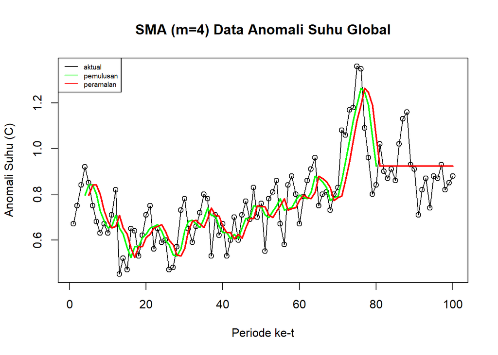

```r
ts.plot(datampdw1.ts, xlab = "Periode ke-t", ylab = "Anomali Suhu (C)",
        main = "SMA (m=4) Data Anomali Suhu Global")
points(datampdw1.ts)
lines(c(data.sma, rep(NA, n_test)), col = "green", lwd = 2)
lines(c(data.ramal, rep(ramalan.sma.test[1], n_test - 1)), col = "red", lwd = 2)
legend("topleft", c("aktual", "pemulusan", "peramalan"), lty = 1,
       col = c("black", "green", "red"), cex = 0.6)
```

### Akurasi Data Latih

```r
m <- 4
error_train.sma <- train.ts - data.ramal[1:length(train.ts)]
idx <- (m + 1):length(train.ts)   # buang periode awal yang NA (m dari SMA + 1 dari pergeseran c(NA, ...))

SSE_train.sma <- sum(error_train.sma[idx]^2)
MSE_train.sma <- mean(error_train.sma[idx]^2)
RMSE_train.sma <- sqrt(MSE_train.sma)
MAPE_train.sma <- mean(abs(error_train.sma[idx] / train.ts[idx])) * 100

akurasi_train.sma <- matrix(c(SSE_train.sma, MSE_train.sma, RMSE_train.sma, MAPE_train.sma))
row.names(akurasi_train.sma) <- c("SSE", "MSE", "RMSE", "MAPE")
colnames(akurasi_train.sma) <- "SMA m=4"
akurasi_train.sma
```

```
##          SMA m=4
## SSE   1.38322500
## MSE   0.01820033
## RMSE  0.13490859
## MAPE 15.22379523
```

Nilai MAPE data latih (≈15,2%) berada pada kategori akurasi “baik”, artinya rata-rata galat pemulusan sekitar 15% dari nilai aktual.

### Akurasi Data Uji

```r
error_test.sma <- test.ts - ramalan.sma.test

SSE_test.sma <- sum(error_test.sma^2)
MSE_test.sma <- mean(error_test.sma^2)
RMSE_test.sma <- sqrt(MSE_test.sma)
MAPE_test.sma <- mean(abs(error_test.sma / test.ts)) * 100

akurasi_test.sma <- matrix(c(SSE_test.sma, MSE_test.sma, RMSE_test.sma, MAPE_test.sma))
row.names(akurasi_test.sma) <- c("SSE", "MSE", "RMSE", "MAPE")
colnames(akurasi_test.sma) <- "Akurasi SMA m=4"
akurasi_test.sma
```

```
##      Akurasi SMA m=4
## SSE       0.23992500
## MSE       0.01199625
## RMSE      0.10952739
## MAPE      9.39829526
```

Nilai MAPE data uji sekitar (≈9,4%), lebih kecil dari data latih. Hal ini terjadi karena hasil ramalan SMA tetap dan nilainya mendekati rata-rata data uji yang naik turun tanpa pola perubahan yang jelas. Ini menunjukkan bahwa anggapan data cenderung tetap cukup sesuai, dengan MAPE < 10% yang termasuk kategori sangat baik.

## 2. Double Moving Average (DMA)

```r
dma  <- SMA(data.sma, n = m)
At   <- 2 * data.sma - dma
Bt   <- (2 / (m - 1)) * (data.sma - dma)
data.dma <- At + Bt
data.ramal2 <- c(NA, data.dma)

h <- 1:n_test
f <- At[length(At)] + Bt[length(Bt)] * h   # forecast h periode ke depan
```

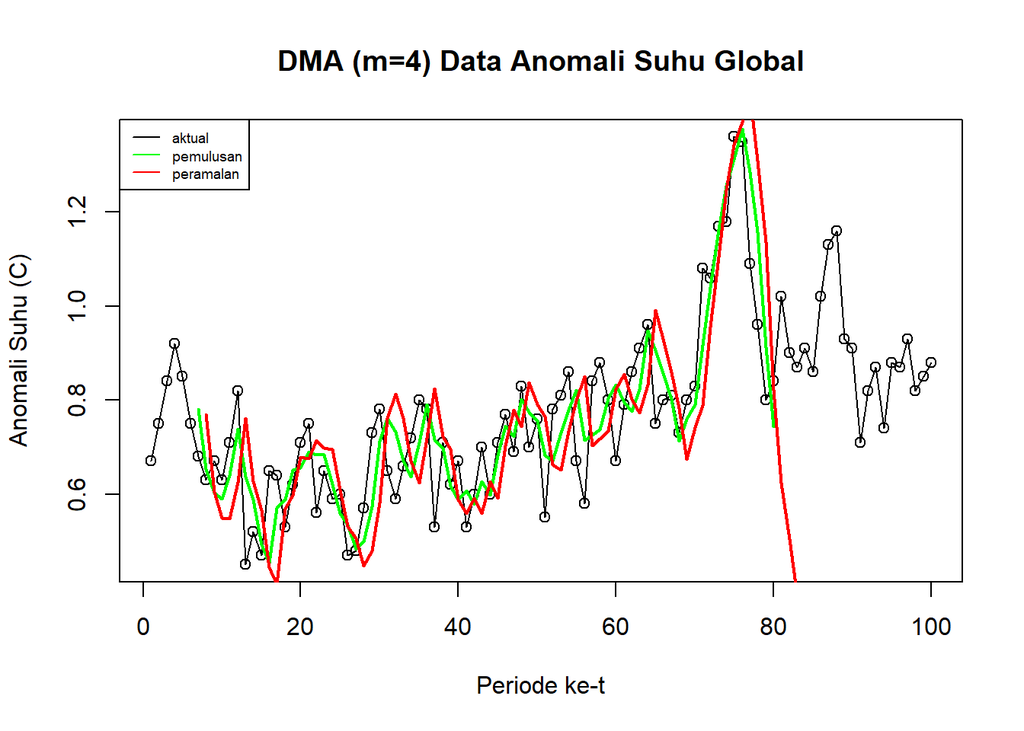

```r
ts.plot(datampdw1.ts, xlab = "Periode ke-t", ylab = "Anomali Suhu (C)",
        main = "DMA (m=4) Data Anomali Suhu Global")
points(datampdw1.ts)
lines(c(At, rep(NA, n_test)), col = "green", lwd = 2)
lines(c(data.ramal2, f[-1]), col = "red", lwd = 2)
legend("topleft", c("aktual", "pemulusan", "peramalan"), lty = 1,
       col = c("black", "green", "red"), cex = 0.6)
```

### Akurasi Data Latih

```r
error_train.dma <- train.ts - data.ramal2[1:length(train.ts)]
idx2 <- (2 * m):length(train.ts)   # buang periode awal yang NA (2 tahap MA + pergeseran c(NA, ...))

SSE_train.dma <- sum(error_train.dma[idx2]^2)
MSE_train.dma <- mean(error_train.dma[idx2]^2)
RMSE_train.dma <- sqrt(MSE_train.dma)
MAPE_train.dma <- mean(abs(error_train.dma[idx2] / train.ts[idx2])) * 100

akurasi_train.dma <- matrix(c(SSE_train.dma, MSE_train.dma, RMSE_train.dma, MAPE_train.dma))
row.names(akurasi_train.dma) <- c("SSE", "MSE", "RMSE", "MAPE")
colnames(akurasi_train.dma) <- "DMA m=4"
akurasi_train.dma
```

```
##          DMA m=4
## SSE   1.64005599
## MSE   0.02246652
## RMSE  0.14988836
## MAPE 17.23443447
```

Pada data latih, MAPE DMA (≈17%) sedikit lebih tinggi daripada SMA (≈15%). Hal ini karena data relatif stabil tanpa tren kuat, sehingga pemulusan ganda DMA tidak meningkatkan akurasi secara signifikan.

### Akurasi Data Uji

```r
error_test.dma <- test.ts - f

SSE_test.dma <- sum(error_test.dma^2)
MSE_test.dma <- mean(error_test.dma^2)
RMSE_test.dma <- sqrt(MSE_test.dma)
MAPE_test.dma <- mean(abs(error_test.dma / test.ts)) * 100

akurasi_test.dma <- matrix(c(SSE_test.dma, MSE_test.dma, RMSE_test.dma, MAPE_test.dma))
row.names(akurasi_test.dma) <- c("SSE", "MSE", "RMSE", "MAPE")
colnames(akurasi_test.dma) <- "Akurasi DMA m=4"
akurasi_test.dma
```

```
##      Akurasi DMA m=4
## SSE        48.693049
## MSE         2.434652
## RMSE        1.560337
## MAPE      160.911287
```

Pada data uji, MAPE DMA melonjak hingga >100%, jauh lebih buruk dari SMA. Hal ini terjadi karena DMA terus memproyeksikan tren linier, sementara data aktual naik-turun tanpa pola yang jelas. Ini menunjukkan bahwa metode berbasis tren tidak selalu lebih akurat, terutama untuk prediksi jangka panjang.

## 3. Single Exponential Smoothing (SES)

Dicoba tiga skenario: α = 0.2, α = 0.7, dan α optimum (dioptimasi otomatis).

```r
ses.1 <- ses(train.ts, h = n_test, alpha = 0.2)
ses.2 <- ses(train.ts, h = n_test, alpha = 0.7)
ses.opt <- ses(train.ts, h = n_test, alpha = NULL)
ses.opt$model   # lihat alpha optimum yang terpilih
```

```
## Simple exponential smoothing
##
## Call:
## ses(y = train.ts, h = n_test, alpha = NULL)
##
##   Smoothing parameters:
##     alpha = 0.7491
##
##   Initial states:
##     l = 0.6966
##
##   sigma:  0.1194
##
##      AIC     AICc      BIC
## 14.53656 14.85235 21.68264
```

Nilai α optimum dari R sebesar ≈0,75 menunjukkan bahwa model lebih mengikuti data terbaru. Hal ini sesuai dengan pola data yang cenderung berubah cukup cepat, sehingga data lama kurang berpengaruh terhadap hasil ramalan.

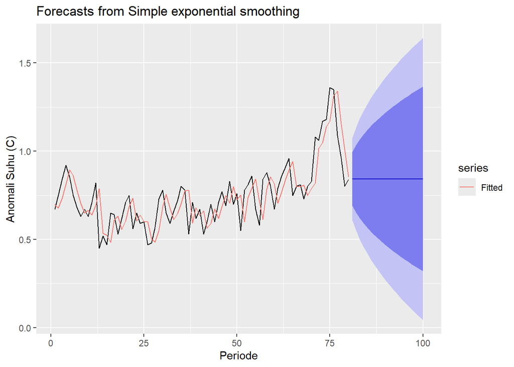

```r
autoplot(ses.opt) +
  autolayer(fitted(ses.opt), series = "Fitted") +
  ylab("Anomali Suhu (C)") + xlab("Periode")
```

### Akurasi Data Latih

```r
acc_ses1   <- accuracy(ses.1, testing$global_temperature_anomaly_C)
acc_ses2   <- accuracy(ses.2, testing$global_temperature_anomaly_C)
acc_sesopt <- accuracy(ses.opt, testing$global_temperature_anomaly_C)
```

```r
acc_ses1["Training set", ]
```

```
##          ME        RMSE         MAE         MPE        MAPE        MASE
##  0.01553604  0.12972232  0.10403874 -0.74685087 14.02473153  1.05237647
##        ACF1
##  0.46214486
```

```r
acc_ses2["Training set", ]
```

```
##           ME         RMSE          MAE          MPE         MAPE         MASE
##  0.002581241  0.118016958  0.097716225 -1.451608005 13.754063109  0.988422761
##         ACF1
##  0.078762507
```

```r
acc_sesopt["Training set", ]
```

```
##           ME         RMSE          MAE          MPE         MAPE         MASE
##  0.002444429  0.117930499  0.096889398 -1.417724217 13.684028552  0.980059208
##         ACF1
##  0.038235769
```

Pada data latih, ketiga skenario memiliki MAPE yang hampir sama (13,68% dan 14,02%). α optimum memberikan MAPE terendah, sesuai karena parameter tersebut dioptimalkan berdasarkan data latih.

### Akurasi Data Uji

```r
acc_ses1["Test set", ]
```

```
##           ME         RMSE          MAE          MPE         MAPE         MASE
##  -0.08805109   0.13930899   0.12423065 -11.24042884  14.45706897   1.25662248
##         ACF1
##           NA
```

```r
acc_ses2["Test set", ]
```

```
##         ME       RMSE        MAE        MPE       MAPE       MASE       ACF1
## 0.05610148 0.12166091 0.08626089 4.92365208 9.00442433 0.87254934         NA
```

```r
acc_sesopt["Test set", ]
```

```
##         ME       RMSE        MAE        MPE       MAPE       MASE       ACF1
## 0.06091820 0.12395575 0.08915092 5.46375889 9.29411844 0.90178268         NA
```

Pada data uji, ses.2 (α=0,7) memiliki MAPE terendah (≈9,0%), disusul ses.opt (≈9,3%) dan ses.1 (≈14,5%). Perbandingan antar-metode dibahas lebih lanjut pada bagian Perbandingan Metode.

## 4. Double Exponential Smoothing (DES)

Karena data memiliki indikasi tren (meski lemah), dicoba juga DES dengan HoltWinters(gamma = FALSE) menggunakan beberapa skenario alpha & beta, serta parameter optimum.

```r
des.1 <- HoltWinters(train.ts, gamma = FALSE, beta = 0.2, alpha = 0.2)
ramalandes1 <- forecast(des.1, h = n_test)

des.2 <- HoltWinters(train.ts, gamma = FALSE, beta = 0.3, alpha = 0.6)
ramalandes2 <- forecast(des.2, h = n_test)

des.opt <- HoltWinters(train.ts, gamma = FALSE)   # alpha & beta dioptimasi otomatis
des.opt$alpha; des.opt$beta
```

```
##     alpha
## 0.8565834
```

```
##       beta
## 0.06893269
```

```r
ramalandesopt <- forecast(des.opt, h = n_test)
```

Hasil optimasi DES menghasilkan α = 0,857 dan β = 0,069. Nilai α yang tinggi menunjukkan model lebih mengikuti perubahan data terbaru, sedangkan β yang rendah menunjukkan komponen tren relatif lemah dan tidak banyak berubah. Hasil ini memperkuat bahwa pola data lebih didominasi fluktuasi daripada tren, sehingga SES lebih sesuai dibandingkan DES.

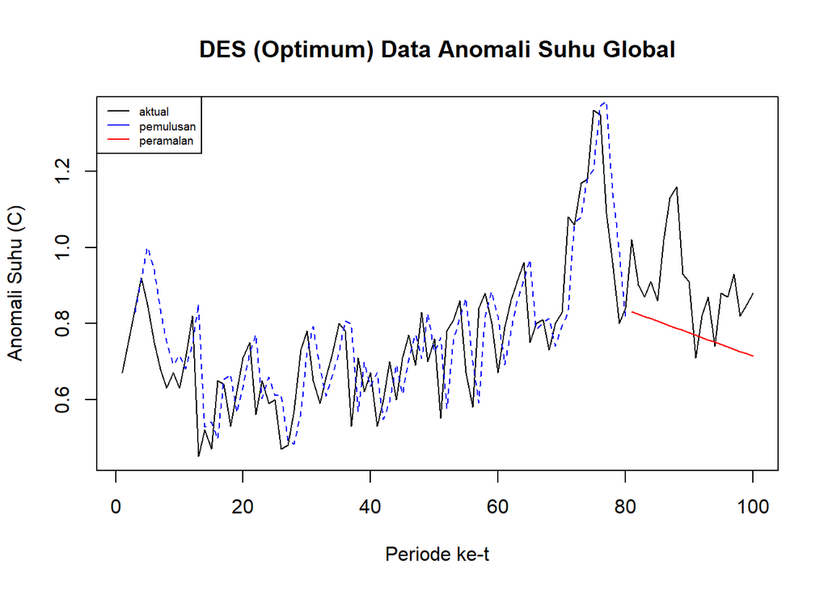

```r
plot(datampdw1.ts, main = "DES (Optimum) Data Anomali Suhu Global",
     xlab = "Periode ke-t", ylab = "Anomali Suhu (C)")
lines(des.opt$fitted[, 1], lty = 2, col = "blue")
lines(ramalandesopt$mean, col = "red")
legend("topleft", c("aktual", "pemulusan", "peramalan"), lty = 1,
       col = c("black", "blue", "red"), cex = 0.6)
```

Plot menunjukkan fitted DES cukup mengikuti data aktual pada data latih, meskipun sedikit tertinggal. Namun, pada data uji, ramalan DES cenderung terus menurun, sementara data aktual justru berfluktuasi dan sempat kembali naik. Hal ini menunjukkan tren negatif di akhir data latih tidak berlanjut, sehingga proyeksi DES kurang sesuai dengan pola aktual.

### Akurasi Data Latih

```r
acc_des1   <- accuracy(ramalandes1, testing$global_temperature_anomaly_C)
acc_des2   <- accuracy(ramalandes2, testing$global_temperature_anomaly_C)
acc_desopt <- accuracy(ramalandesopt, testing$global_temperature_anomaly_C)
```

```r
acc_des1["Training set", ]
```

```
##          ME        RMSE         MAE         MPE        MAPE        MASE
## -0.02540318  0.16773535  0.13052435 -5.94269164 18.24987265  1.32028475
##        ACF1
##  0.63238945
```

```r
acc_des2["Training set", ]
```

```
##          ME        RMSE         MAE         MPE        MAPE        MASE
## -0.01120012  0.13376724  0.10586075 -2.88413172 14.98083077  1.07080658
##        ACF1
##  0.17314519
```

```r
acc_desopt["Training set", ]
```

```
##          ME        RMSE         MAE         MPE        MAPE        MASE
## -0.01870574  0.12688998  0.09970382 -4.27414319 14.46677637  1.00852776
##        ACF1
## -0.01537451
```

Pada data latih, des.1 dan des.2 menghasilkan MAPE 18,25% dan 14,98%, sedangkan des.opt paling rendah di 14,47%.

### Akurasi Data Uji

```r
acc_des1["Test set", ]
```

```
##          ME        RMSE         MAE         MPE        MAPE        MASE
##  -0.2060702   0.2334590   0.2135014 -24.4954929  25.1412694   2.1596176
##        ACF1
##          NA
```

```r
acc_des2["Test set", ]
```

```
##          ME        RMSE         MAE         MPE        MAPE        MASE
##   0.8871416   0.9792905   0.8871416 100.3342708 100.3342708   8.9736470
##        ACF1
##          NA
```

```r
acc_desopt["Test set", ]
```

```
##         ME       RMSE        MAE        MPE       MAPE       MASE       ACF1
##  0.1314573  0.1648045  0.1385052 13.5505970 14.5369585  1.4010124         NA
```

Pada data uji, des.1 memiliki MAPE 25,14%, sedangkan des.2 mencapai 100,33%. Sementara itu, des.opt hanya 14,54% dan hasilnya lebih konsisten dengan data latih. Hal ini menunjukkan bahwa bobot tren yang lebih besar justru menurunkan akurasi, sehingga des.opt menjadi pilihan terbaik.

## Holt-Winters

```r
# membuat ulang objek `ts` khusus dengan `frequency = 12`
train.ts.musiman <- ts(training$global_temperature_anomaly_C, frequency = 12)
test.ts.musiman  <- ts(testing$global_temperature_anomaly_C, frequency = 12)
```

## 5. Winter Aditif

```r
# skenario parameter manual (contoh)
winter.add1 <- HoltWinters(train.ts.musiman, alpha = 0.2, beta = 0.1,
                            gamma = 0.1, seasonal = "additive")

# skenario parameter optimum (dioptimasi otomatis oleh R)
winter.add.opt <- HoltWinters(train.ts.musiman, seasonal = "additive")
winter.add.opt$alpha; winter.add.opt$beta; winter.add.opt$gamma
```

```
##     alpha
## 0.5955113
```

```
##        beta
## 0.007435916
```

```
##     gamma
## 0.5613276
```

```r
fc.add1   <- predict(winter.add1,   n.ahead = n_test)
fc.add.opt <- predict(winter.add.opt, n.ahead = n_test)
```

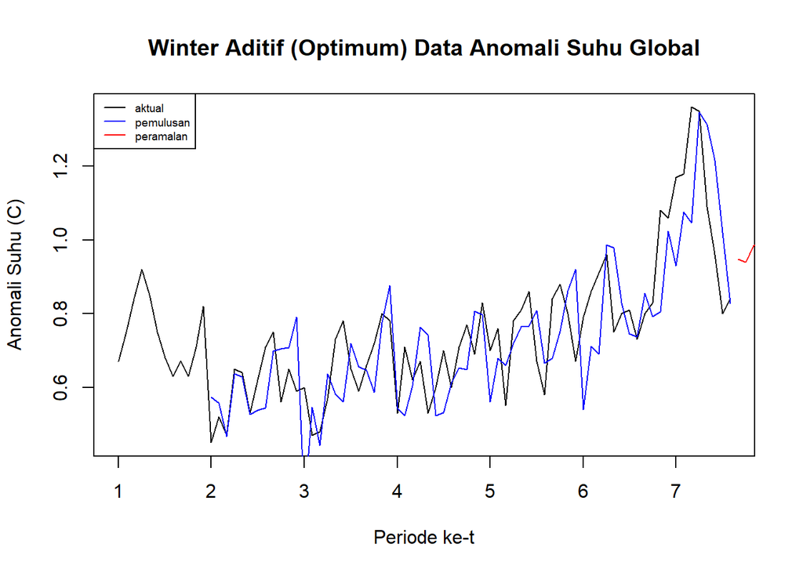

```r
plot(train.ts.musiman, main = "Winter Aditif (Optimum) Data Anomali Suhu Global", xlab = "Periode ke-t",
     ylab = "Anomali Suhu (C)")
lines(winter.add.opt$fitted[, 1], col = "blue")
lines(fc.add.opt, col = "red")
legend("topleft", c("aktual", "pemulusan", "peramalan"),
       col = c("black", "blue", "red"), lty = 1, cex = 0.6)
```

### Akurasi Data Latih

```r
hitung_akurasi_latih <- function(model, train_ts) {
  fit <- model$fitted[, 1]
  actual <- train_ts[(length(train_ts) - length(fit) + 1):length(train_ts)]
  err <- actual - fit
  SSE <- sum(err^2)
  MSE <- mean(err^2)
  RMSE <- sqrt(MSE)
  MAPE <- mean(abs(err / actual)) * 100
  matrix(c(SSE, MSE, RMSE, MAPE), dimnames = list(c("SSE","MSE","RMSE","MAPE"), "Akurasi Holt Winters Aditif"))
}

akurasi_train.add1   <- hitung_akurasi_latih(winter.add1, train.ts.musiman)
akurasi_train.addopt <- hitung_akurasi_latih(winter.add.opt, train.ts.musiman)
akurasi_train.add1
```

```
##      Akurasi Holt Winters Aditif
## SSE                   1.50583119
## MSE                   0.02214458
## RMSE                  0.14881054
## MAPE                 14.86275395
```

```r
akurasi_train.addopt
```

```
##      Akurasi Holt Winters Aditif
## SSE                   1.29422691
## MSE                   0.01903275
## RMSE                  0.13795923
## MAPE                 14.64377441
```

### Akurasi Data Uji

```r
hitung_akurasi_uji <- function(forecast_obj, actual_test) {
  err <- as.numeric(actual_test) - as.numeric(forecast_obj)
  SSE <- sum(err^2)
  MSE <- mean(err^2)
  RMSE <- sqrt(MSE)
  MAPE <- mean(abs(err / actual_test)) * 100
  matrix(c(SSE, MSE, RMSE, MAPE), dimnames = list(c("SSE","MSE","RMSE","MAPE"), "Akurasi Holt Winters Aditif"))
}

akurasi_test.add1   <- hitung_akurasi_uji(fc.add1,   testing$global_temperature_anomaly_C)
akurasi_test.addopt <- hitung_akurasi_uji(fc.add.opt, testing$global_temperature_anomaly_C)
akurasi_test.add1
```

```
##      Akurasi Holt Winters Aditif
## SSE                    2.4611130
## MSE                    0.1230556
## RMSE                   0.3507929
## MAPE                  36.9987398
```

```r
akurasi_test.addopt
```

```
##      Akurasi Holt Winters Aditif
## SSE                   0.28056680
## MSE                   0.01402834
## RMSE                  0.11844129
## MAPE                  9.89234714
```

Pada data latih, model manual dan optimum memiliki MAPE yang hampir sama (14,86% dan 14,64%). Namun pada data uji, MAPE model manual naik menjadi 37,00%, sedangkan model optimum hanya 9,89%. Perbedaan ini terutama dipengaruhi oleh nilai γ, di mana γ manual terlalu kecil sehingga pola musiman kurang menyesuaikan perubahan data. Sebaliknya, γ optimum yang lebih besar membuat model lebih cepat menyesuaikan pola musiman, sehingga menghasilkan ramalan yang lebih akurat.

## 6. Winter Multiplikatif

```r
winter.mult.opt <- HoltWinters(train.ts.musiman, seasonal = "multiplicative")
winter.mult.opt$alpha; winter.mult.opt$beta; winter.mult.opt$gamma
```

```
##     alpha
## 0.1365612
```

```
##       beta
## 0.09531269
```

```
##     gamma
## 0.6835911
```

```r
xhat.multopt <- winter.mult.opt$fitted[, 1]

idx_hw <- (frequency(train.ts.musiman) + 1):length(train.ts.musiman)  # buang 1 musim awal (periode inisialisasi)
```

```r
fc.mult.opt <- predict(winter.mult.opt, n.ahead = n_test)
```

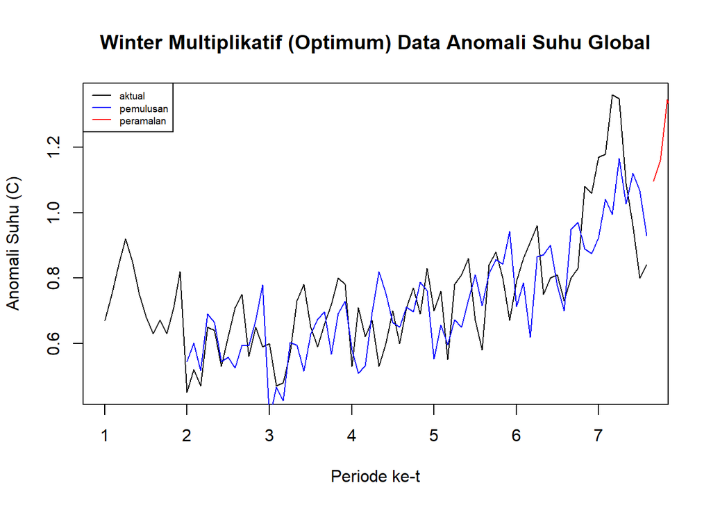

```r
plot(train.ts.musiman, main = "Winter Multiplikatif (Optimum) Data Anomali Suhu Global",
     xlab = "Periode ke-t", ylab = "Anomali Suhu (C)")
lines(winter.mult.opt$fitted[, 1], col = "blue")
lines(fc.mult.opt, col = "red")
legend("topleft", c("aktual", "pemulusan", "peramalan"),
       col = c("black", "blue", "red"), lty = 1, cex = 0.6)
```

### Akurasi Data Latih

```r
error_train.hwmultopt <- train.ts.musiman[idx_hw] - xhat.multopt
SSE_train.hwmultopt  <- sum(error_train.hwmultopt^2)
MSE_train.hwmultopt  <- mean(error_train.hwmultopt^2)
RMSE_train.hwmultopt <- sqrt(MSE_train.hwmultopt)
MAPE_train.hwmultopt <- mean(abs(error_train.hwmultopt / train.ts.musiman[idx_hw])) * 100

akurasi_train.hwmultopt <- matrix(c(SSE_train.hwmultopt, MSE_train.hwmultopt, RMSE_train.hwmultopt, MAPE_train.hwmultopt))
row.names(akurasi_train.hwmultopt) <- c("SSE", "MSE", "RMSE", "MAPE")
colnames(akurasi_train.hwmultopt) <- "Holt Winters Multiplikatif"
akurasi_train.hwmultopt
```

```
##      Holt Winters Multiplikatif
## SSE                  1.30025102
## MSE                  0.01912134
## RMSE                 0.13827993
## MAPE                14.81694779
```

### Akurasi Data Uji

```r
error_test.hwmultopt <- testing$global_temperature_anomaly_C - as.numeric(fc.mult.opt)
SSE_test.hwmultopt  <- sum(error_test.hwmultopt^2)
MSE_test.hwmultopt  <- mean(error_test.hwmultopt^2)
RMSE_test.hwmultopt <- sqrt(MSE_test.hwmultopt)
MAPE_test.hwmultopt <- mean(abs(error_test.hwmultopt / testing$global_temperature_anomaly_C)) * 100

akurasi_test.hwmultopt <- matrix(c(SSE_test.hwmultopt, MSE_test.hwmultopt, RMSE_test.hwmultopt, MAPE_test.hwmultopt))
row.names(akurasi_test.hwmultopt) <- c("SSE", "MSE", "RMSE", "MAPE")
colnames(akurasi_test.hwmultopt) <- "Akurasi Holt Winters Multiplikatif"
akurasi_test.hwmultopt
```

```
##      Akurasi Holt Winters Multiplikatif
## SSE                           4.9666309
## MSE                           0.2483315
## RMSE                          0.4983288
## MAPE                         51.2794489
```

Model multiplikatif optimum memiliki MAPE data latih yang hampir sama dengan model aditif (14,82% dan 14,64%), tetapi pada data uji jauh lebih buruk (51,28% dan 9,89%). Hal ini karena model multiplikatif menganggap pola musiman berubah mengikuti level data, sedangkan pada anomali suhu fluktuasinya cenderung tetap. Akibatnya, ramalan multiplikatif kurang sesuai dengan pola data uji.

## Perbandingan Metode

```r
# fungsi akurasi generik: bandingkan actual dengan forecast
hitung_akurasi <- function(actual, forecast) {
  err <- actual - as.numeric(forecast)
  c(SSE  = sum(err^2),
    MSE  = mean(err^2),
    RMSE = sqrt(mean(err^2)),
    MAPE = mean(abs(err / actual)) * 100)
}

actual_test <- testing$global_temperature_anomaly_C

# daftar semua ramalan data uji, satu per model
daftar_ramalan <- list(
  SMA_m4          = ramalan.sma.test,
  DMA_m4          = f,
  SES_a02         = ses.1$mean,
  SES_a07         = ses.2$mean,
  SES_optimum     = ses.opt$mean,
  DES_a02b02      = ramalandes1$mean,
  DES_a06b03      = ramalandes2$mean,
  DES_optimum     = ramalandesopt$mean,
  HW_add_manual   = fc.add1,
  HW_add_optimum  = fc.add.opt,
  HW_mult_optimum = fc.mult.opt
)

# terapkan hitung_akurasi() ke semua model sekaligus
tabel_perbandingan <- t(sapply(daftar_ramalan, hitung_akurasi, actual = actual_test))
tabel_perbandingan <- as.data.frame(round(tabel_perbandingan, 4))

# urutkan dari MAPE terkecil (terbaik)
tabel_perbandingan[order(tabel_perbandingan$MAPE), ]
```

```
##                     SSE    MSE   RMSE     MAPE
## SES_a07          0.2960 0.0148 0.1217   9.0044
## SES_optimum      0.3073 0.0154 0.1240   9.2941
## SMA_m4           0.2399 0.0120 0.1095   9.3983
## HW_add_optimum   0.2806 0.0140 0.1184   9.8923
## SES_a02          0.3881 0.0194 0.1393  14.4571
## DES_optimum      0.5432 0.0272 0.1648  14.5370
## DES_a02b02       1.0901 0.0545 0.2335  25.1413
## HW_add_manual    2.4611 0.1231 0.3508  36.9987
## HW_mult_optimum  4.9666 0.2483 0.4983  51.2794
## DES_a06b03      19.1802 0.9590 0.9793 100.3343
## DMA_m4          48.6930 2.4347 1.5603 160.9113
```